# Assignment 8: Visualization - Making a bar race

*How to do it?*:

- Open the Rmarkdown file of this assignment (link) in Rstudio.
- Right under each **question**, insert a code chunk (you can use the hotkey `Ctrl + Alt + I` to add a code chunk) and code the solution for the question.
- `Knit` the rmarkdown file (hotkey: `Ctrl + Alt + K`) to export an html.
- Publish the html file to your Githiub Page.

*Submission*: Submit the link on Github of the assignment to Canvas

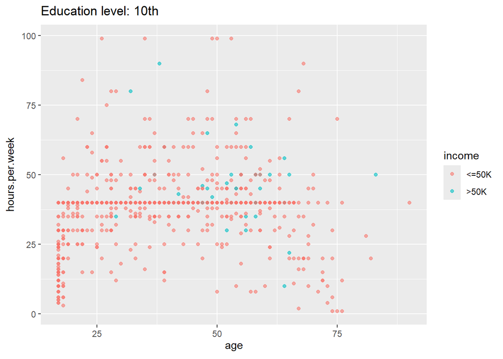

   ```r
   library(ggplot2)
   library(gganimate)
   library(gifski)
   library(readr)
   library(dplyr)

   df <- read_csv("C:/Users/student/Downloads/adult_census.csv")

   df %>%
     ggplot(aes(x = age, y = hours.per.week, color = income)) +
     geom_point(alpha = 0.6) +
     transition_states(education,
                       transition_length = 2,
                       state_length = 1) +
     labs(title = "Education level: {closest_state}")
   ```

3. Use the WHO’s dataset at [this link](https://covid19.who.int/WHO-COVID-19-global-data.csv). Make a top-10 bar race by months between countries on the number of deaths by Covid 19 in 2021.

   ```r
   df <- read_csv("C:/Users/student/Downloads/WHO-COVID-19-global-data.csv")
   names(df)
   ```

   ```
   ## [1] "Date_reported"     "Country_code"      "Country"
   ## [4] "WHO_region"        "New_cases"         "Cumulative_cases"
   ## [7] "New_deaths"        "Cumulative_deaths"
   ```

   ```r
   library(dplyr)
   library(readr)
   library(lubridate)
   top10_monthly <- df %>%
     mutate(
       Date_reported = as.Date(Date_reported),
       year = year(Date_reported),
       month_date = floor_date(Date_reported, unit = "month"),
       month_label = format(month_date, "%b %Y")
     ) %>%
     filter(year == 2021) %>%
     group_by(month_label, Country) %>%
     summarise(month_deaths = sum(New_deaths, na.rm = TRUE), .groups = "drop") %>%
     group_by(month_label) %>%
     slice_max(order_by = month_deaths, n = 10, with_ties = FALSE) %>%
     arrange(month_label, month_deaths) %>%
     mutate(rank = row_number()) %>%
     ungroup()
   ```

   ```r
   p <- ggplot(top10_monthly,
               aes(x = month_deaths,
                   y = reorder(Country, rank),
                   fill = Country)) +
     geom_col() +
     labs(
       x = "Number of deaths in month",
       y = NULL,
       title = "Top-10 countries by Covid-19 deaths\n{closest_state}"
     ) +
     theme_minimal() +
     theme(
       legend.position = "none",
       plot.title = element_text(size = 16, face = "bold")
     ) +
     transition_states(
       month_label,
       transition_length = 2,
       state_length = 1
     )

   library(gganimate)
   library(gifski)

   anim <- animate(
     p,
     nframes = 200, fps = 10,
     width = 800, height = 600, units = "px",
     renderer = gifski_renderer()
   )

4. ake a bar race using a dataset of your own interest. You may use the dataset that we use in class (https://covidtracking.com/data/download/all-states-history.csv) but you should make a different bar racev from ones in the slides.

```r
library(tidyverse)
```

```r
library(lubridate)
library(gganimate)
library(gifski)
library(readr)

df <- read_csv("https://covidtracking.com/data/download/all-states-history.csv")
top10_hosp <- df %>%
  mutate(date = ymd(date)) %>%
  filter(year(date) == 2021) %>%
  filter(!is.na(hospitalizedCurrently)) %>%
  select(date, state, hospitalizedCurrently) %>%
  group_by(date, state) %>%
  summarise(hosp = max(hospitalizedCurrently, na.rm = TRUE), .groups = "drop") %>%
  group_by(date) %>%
  slice_max(order_by = hosp, n = 10, with_ties = FALSE) %>%
  arrange(date, hosp) %>%
  mutate(
    rank = row_number(),
    date_label = format(date, "%b %d %Y")
  ) %>%
  ungroup()
```

```r
p <- ggplot(top10_hosp,
            aes(x = hosp,
                y = reorder(state, rank),
                fill = state)) +
  geom_col() +
  labs(
    x = "Current Covid-19 hospitalizations",
    y = NULL,
    title = "Top-10 states by current Covid-19 hospitalizations\n{closest_state}"
  ) +
  theme_minimal() +
  theme(
    legend.position = "none",
    plot.title = element_text(size = 16, face = "bold")
  ) +
  transition_states(
    date_label,
    transition_length = 2,
    state_length = 1
  )

library(gganimate)
library(gifski)

anim <- animate(
  p,
  nframes = 200, fps = 10,
  width = 800, height = 600, units = "px",
  renderer = gifski_renderer()
)

anim_save("C:/Users/student/Desktop/bar_race.gif", animation = anim)
```

[output not shown]